# Lab-01

# Model

12. Let us focus on the imports from Australia, i.e., the following should be performed on the subset of meds where the Country is Australia. We want to predict the total monthly VFD import value (aggregated over all HS codes) over time. In order to make interpretation easier, scale the VFD variable such that its unit are millions of NZD. We are going to limit ourselves to simple linear regression.

Generate training and test sets, where the training set is 92% of the data and the test set is only 8% of the data. Choose the dataset partitions such that you are testing with future data (relative to training).

Fit two models to the training data: a simple overall mean and a linear regression model with the Date as a predictor variable.

Calculate RMSE for the predictions of the two models on the test set. Which model performs better?

```r
# Step 1: Filter the data for Australia
aus_data <- meds[meds$Country == 'Australia', ]

# Step 2: Scale VFD to million
aus_data$VFD_millions <- aus_data$VFD / 10^6

# Step 3: Aggregate the VFD over all HS codes by date
agg_aus_data <- aggregate(VFD_millions ~ Date, aus_data, sum)

# Step 4: Sort data by date
sorted_aus_data <- agg_aus_data[order(agg_aus_data$Date), ]

# Step 5: Divide the data into training and test sets
train_size <- floor(0.92 * nrow(sorted_aus_data))  # training size
train_data <- sorted_aus_data[1:train_size, ]
test_data <- sorted_aus_data[(train_size + 1):nrow(sorted_aus_data), ]

# Step 6: Fit the mean model
mean_model <- mean(train_data$VFD_millions)

# Step 7: Compute the RMSE for the mean model
rmse_mean <- sqrt(mean((test_data$VFD_millions - mean_model)^2))

# Step 8: Fit the linear regression model
lm_model <- lm(VFD_millions ~ Date, data = train_data)

# Step 9: Predict the test set using the linear regression model
lm_predictions <- predict(lm_model, newdata = test_data)

# Step 10: Compute the RMSE for the linear model
rmse_lm <- sqrt(mean((test_data$VFD_millions - lm_predictions)^2))

# Step 11: Print RMSEs
print(paste("RMSE for mean model:", round(rmse_mean, 6)))
```

```
## [1] "RMSE for mean model: 4.355018"
```

```r
print(paste("RMSE for linear model:", round(rmse_lm, 6)))
```

```
## [1] "RMSE for linear model: 4.315403"
```

Plot the model predictions, it should look something like this (dotted line denotes the split between the training and test data, you don’t need worry about creating the pink label):

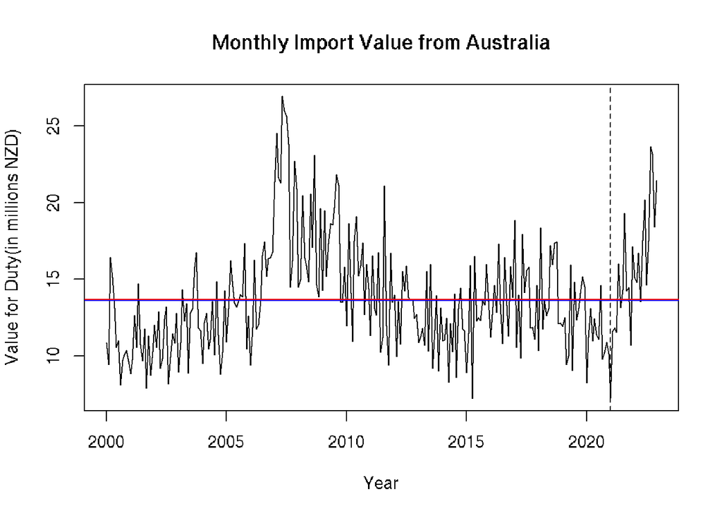

```r
# Plot the VFD values over time for Australia
plot(sorted_aus_data$Date, sorted_aus_data$VFD_millions, type = "l", col = "black", xlab = "Year", ylab = "Value for Duty(in millions NZD)", main = "Monthly Import Value from Australia")

# Add a vertical line to denote the split between training and test data
abline(v = sorted_aus_data$Date[train_size], col = "black", lty = 2)

# Add the mean model prediction as a horizontal line
abline(h = mean_model, col = "blue", lty = 1)

# Add the linear model predictions as red line
abline(h=lm_predictions, col = "red", lty = 1)
```

Do you think the linear model is sensible? Can you explain the obtained results?

I think the linear model is not very sensible because its RMSE value is not significantly better than the mean model’s RMSE value, indicating that the linear model only slightly outperforms the mean model. Additionally, from the plot, we can observe that the overall trend of the monthly import value is changing over time. From around 2000 to 2008, the trend is upward, while from 2008 to around 2015, it is downward, possibly due to the impact of the economic crisis. Then, from 2015 to 2018, there is a slight upward trend, followed by another decline, reaching the lowest point in the 20-year period around 2021, possibly due to the effects of the pandemic. After 2021, the value starts to rise rapidly. Therefore, a simple linear model cannot capture the varying trends in the monthly import value over the 20-year period. Additionally, as this data exhibits seasonal patterns, a linear model alone may not be sensible enough to accurately capture these seasonal variations.

# Summary

In this data analysis assignment, we conducted a series of analyses on medication import data, aiming to explore patterns, predict trends, and evaluate the effectiveness of linear regression models. Here are our key findings:

Sensibility of Linear Model: The linear regression model’s performance was not significantly better than the mean model, as reflected in their similar RMSE values. The plot illustrated that the overall trend of monthly import values changed over time, indicating a non-linear pattern. Moreover, the data exhibited seasonal variations, which the linear model could not fully capture.

To enhance the analysis’s consistency, we can handle missing data, standardize VFD units, and address outliers that may distort results. Additionally, considering normalization can facilitate meaningful comparisons between HS codes.

To further improve predictions, we recommend exploring advanced time series models, which are better suited to capture seasonal variations and complex trends. Additionally, investigating the impact of economic events and other external factors on import patterns could provide deeper insights.